# lab_5_Kovalenko (1)

### Лабораторна робота №5

**Мета:** *освоїти роботу зі списками*

### Завдання 1

Жив-був капелюх. У капелюсі не було кролика, натомість був список із п'яти чисел: `1`, `2`, `3`, `4` та `5`.

Ваше завдання:

- напишіть рядок коду, що пропонує користувачеві замінити число всередині списку цілим числом, введеним користувачем (крок 1)
- напишіть рядок коду, який видаляє останній елемент зі списку (крок 2)
- напишіть рядок коду, який друкує довжину існуючого списку (крок 3).

Чи готові до цього випробування?

```python
hat_list = [1, 2, 3, 4, 5]

number = int(input("Enter a number: "))

hat_list[int(len(hat_list) // 2)] = number
print(hat_list)

del hat_list [-1]

print(hat_list)
```

[output not shown]

### Сортування списків

Поряд з можливістю реалізувати будь-який алгоритм сортування, у python існують вбудовані методи для сортування списків.

```python
my_list = [1, 7, 23, 34, 0]
my_list.sort()
print(my_list)
my_list.reverse()
print(my_list)
```

[0, 1, 7, 23, 34]

[34, 23, 7, 1, 0]

### Завдання 2

Написати програму сортування списку у порядку зростання методом бульбашки.

```python
def bubble_sort(my_list):
    n = len(my_list)
    for i in range(n-1):
        for j in range(n-i-1):
            if my_list[j] > my_list[j+1]:
                my_list[j], my_list[j+1] = my_list[j+1], my_list[j]
    return my_list

my_list = [1, 7, 23, 34, 0]
print("Оригінальний список:", my_list)
sorted_list = bubble_sort(my_list)
print("Відсортований список:", sorted_list)
```

```
Оригінальний список: [1, 7, 23, 34, 0]
Відсортований список: [0, 1, 7, 23, 34]
```

### Конструкції `in` та `not in`

### Завдання 3

Уявіть список - не дуже довгий, не дуже складний, просто звичайний список, що містить деякі цілі числа. Деякі з цих чисел можуть повторюватись, і це ключ до розгадки. Ми не хочемо повторень. Ми хочемо, щоб їх видалили.

Ваше завдання – написати програму, яка видаляє всі дублікати чисел зі списку. Ціль полягає в тому, щоб скласти список, в якому всі числа зустрічаються не більше одного разу.

```python
my_list = [1, 2, 4, 4, 1, 4, 2, 6, 2, 9]

# Видалення дублікатів
unique_set = set(my_list)

# Перетворення списку та його відсортування
unique_list = sorted(list(unique_set))

print("The list with unique elements only:")
print(unique_list)
```

```
The list with unique elements only:
[1, 2, 4, 6, 9]
```

## Багатовимірні списки. Генератори списків

### Приклад

Уявіть, що Ви розробляєте програмне забезпечення автоматичної метеостанції. Прилад фіксує температуру повітря щогодини та робить це протягом місяця. Це дає Вам загалом 24 × 31 = 744 значення. Спробуємо скласти список, здатний зберігати ці результати.

```python
# Взяла код з методички
temps = [[0.0 for h in range(24)] for d in range(31)]

# Взяла рандомні значення температур
import random

for d in range(31):
    for h in range(24):
        temps[d][h] = round(random.uniform(-10.0, 35.0), 1)

for day in temps:
   print(day)
```

```
[-5.3, 32.8, 32.5, 2.3, 25.3, -3.1, 12.7, 17.8, -0.3, 24.0, 20.5, 27.7, 5.2, 21.5, -4.7, -4.8, -2.1, 3.4, 21.4, -0.2, -8.0, 6.5, 5.7, 6.8]
[3.9, 16.7, -4.4, 7.7, 6.5, -9.7, 14.8, 15.8, 30.2, -6.4, 19.7, 12.6, 24.1, -0.2, 10.7, 16.2, 14.6, 13.0, 27.7, 1.4, -2.4, -2.2, 10.7, 3.7]
[8.8, 8.7, 34.9, -3.1, 22.9, 18.1, 20.4, 30.1, 17.2, -8.8, 16.5, 11.9, 0.4, 1.6, 4.0, 13.7, 5.8, -7.8, -1.3, -2.0, 6.4, 4.7, 14.1, 16.1]
[26.9, 31.4, -2.3, 26.2, 16.2, 32.9, 28.9, 2.4, 33.5, -5.0, 13.8, 33.2, 30.8, 32.8, 28.9, 7.9, 1.1, 12.3, 27.4, 27.0, 18.6, 6.8, -0.7, -4.9]
[28.1, 29.2, 1.4, 12.3, 16.4, 9.3, 13.5, 21.1, 32.4, 21.8, 22.6, -1.6, 4.7, 32.9, 22.7, 29.1, 16.2, 23.8, -5.3, -4.3, 20.8, 30.1, 8.2, -5.8]
[24.3, 20.9, 28.6, 3.5, -1.7, 28.3, -4.4, 17.7, 30.6, 30.2, 7.8, -3.4, 7.6, 10.5, -6.0, 20.7, -6.4, 6.3, -9.8, -9.4, 32.3, 13.3, 1.6, -3.1]
[16.4, 6.8, 15.9, -0.8, 31.1, 3.0, -6.3, 8.5, -6.6, 6.4, 28.3, 23.6, -0.6, -1.9, 15.6, 20.3, 32.3, 14.4, 10.6, 1.4, 12.2, 12.2, 5.3, 9.9]
[34.2, -9.2, -4.8, 24.1, 24.4, 17.3, 6.6, 16.3, 24.0, 5.5, 29.6, 26.8, 24.6, 20.9, 30.7, 30.7, 1.2, 21.2, 26.9, -3.1, 18.0, -0.0, 19.5, -5.0]
[-3.3, 21.5, 9.5, 18.6, -3.3, 7.5, -4.2, 24.8, 33.3, 4.4, -3.3, -0.7, -0.0, 34.4, 27.9, -5.9, 25.6, 34.9, 6.0, 14.3, 22.0, 28.4, 15.1, 3.1]
[0.3, 34.2, 29.3, 31.1, 4.7, 15.6, 19.7, 24.0, 18.8, 29.7, 7.7, 17.9, 11.7, -3.4, 9.5, 14.9, 8.5, 1.3, 4.2, 16.8, 31.8, 18.0, 13.0, -3.3]
[33.3, 25.1, 23.0, 11.2, -7.9, 27.6, 28.9, 13.6, 7.6, 32.2, 31.9, 27.8, -4.2, -3.8, 3.2, -1.2, 22.1, -4.2, 6.1, 14.6, 0.5, 7.6, 24.5, 27.2]
[13.5, 12.7, -0.3, 33.7, -7.3, 22.1, 24.9, 5.4, -0.2, -5.3, 20.6, 18.1, 11.1, 33.6, -5.5, 21.8, 4.1, 31.0, 3.6, 18.8, -6.8, 16.4, 33.8, 34.7]
[9.6, 18.5, -8.7, 5.2, 21.1, 12.0, 33.8, 26.1, -5.7, 27.2, 17.5, -9.2, -5.1, 16.4, 23.2, 19.7, -8.5, 22.5, -2.0, 32.1, 30.6, 8.6, 33.7, 13.8]
[34.4, 11.7, 22.0, 10.6, 7.6, 11.7, -8.3, 32.4, -2.4, -6.5, 10.5, 4.2, 25.5, 24.7, 19.7, 9.6, 32.2, 4.1, -1.8, -1.5, -4.4, 10.0, 31.5, -3.0]
[-5.9, 16.0, 19.9, 31.0, -8.7, 4.2, 5.4, 8.8, 10.1, -0.9, 27.7, 9.3, 3.9, 3.6, 30.0, -5.6, 16.3, -9.5, 30.7, 2.2, -3.9, 28.8, -1.0, 33.0]
[-0.8, 10.6, 33.7, 15.4, 14.4, -7.4, 21.8, 5.2, 21.8, 24.2, 11.8, 11.7, 11.7, 21.8, 34.3, 13.6, 2.1, 25.0, -7.9, -9.8, 8.5, 3.6, 28.6, 29.2]
[19.0, 25.7, 2.2, -8.2, 9.0, 31.7, 14.9, 28.9, 10.8, 33.2, 26.5, 18.5, 4.6, 31.6, 21.4, 30.4, 28.8, -5.1, 22.8, 9.3, 33.9, 13.2, 27.7, -1.5]
[34.7, 9.8, -5.5, 24.7, 14.7, 16.5, 5.0, 32.8, 34.6, 22.0, 24.5, -8.1, 10.0, 10.1, 0.4, -8.9, 21.5, 30.5, 20.0, 17.5, 6.9, -0.1, 17.8, -3.8]
[2.0, 8.5, 1.4, -8.7, -0.5, 25.4, 27.6, -2.8, 1.2, -2.7, 18.0, 2.3, 0.4, 2.5, 24.7, 5.8, 0.9, -0.1, 7.5, 9.1, 33.0, 18.1, 11.6, -4.0]
[18.6, 6.8, 20.9, 7.1, 31.1, 18.6, 5.0, 13.7, 6.9, -8.4, 27.3, -5.4, 33.4, -2.4, 5.6, 26.4, 5.0, -3.3, 6.9, -2.7, 34.2, 19.7, 19.9, -9.3]
[8.0, 8.2, 15.0, 3.8, 11.5, 11.9, 31.9, 8.0, 9.7, 20.2, 3.9, 16.9, 18.5, 20.6, 23.6, 34.6, 24.6, 8.4, 14.7, 3.1, -8.1, 14.6, -0.5, 34.3]
[-0.9, 11.3, 26.6, 4.5, 5.1, 21.6, -4.3, 2.6, 2.2, -4.0, -9.3, 5.4, -3.6, 21.3, -5.1, 31.6, 16.9, 33.4, 17.3, 16.3, 30.2, -7.5, 27.1, 4.7]
[33.8, 13.0, 29.8, 30.2, 11.2, -5.0, 1.3, 26.6, 1.0, 10.4, 10.7, 18.4, 3.5, 8.5, -1.5, 3.4, 4.5, 28.2, -1.0, 23.5, -3.9, 22.4, -9.3, -2.5]
[24.0, 11.9, -1.9, 19.7, 5.0, 15.9, 6.1, -5.6, 6.5, 13.3, 24.0, 18.6, 25.7, -5.8, -3.5, 3.3, -3.8, 10.1, 10.0, 17.9, 6.3, 26.3, 13.6, 33.1]
[26.4, 24.9, 7.8, -5.8, -7.4, 32.0, -3.5, 34.4, 14.0, -10.0, 9.8, 22.8, 3.6, 28.8, 10.8, -6.4, -1.9, 6.1, 28.4, 25.4, 20.5, 0.2, -5.7, 27.8]
[-3.6, 28.1, 16.6, 15.8, 2.5, 7.6, -2.3, 15.4, 21.9, -6.4, 30.8, 33.5, 1.6, 8.9, 22.3, 23.6, 5.7, 2.3, 13.3, 16.3, 11.5, 12.9, -4.7, 33.6]
[-3.7, 33.2, 2.3, 33.4, 24.6, 23.5, -0.1, -5.8, -8.8, 13.1, 18.8, 26.3, 16.6, 15.7, -9.7, -9.8, 2.4, 19.0, 23.6, -0.0, 34.2, 14.9, 24.9, -2.0]
[4.2, 11.3, 30.1, 1.6, 24.8, 27.7, -0.7, 30.0, 25.6, 20.9, 10.0, 23.5, -7.7, 11.4, 34.5, 6.0, 23.0, 17.0, 18.5, 17.3, 33.2, 3.2, 16.8, 28.8]
[-0.8, 6.2, 33.4, 10.2, 17.3, 20.0, 0.0, 1.9, 28.6, 28.7, 0.2, -9.0, -2.9, 16.7, 7.6, 25.0, -6.6, 34.9, 22.3, 19.1, 9.1, 30.7, 11.3, -5.5]
[5.6, 15.6, -2.9, 24.6, -9.6, 26.2, 2.3, 29.4, 7.4, -4.3, 1.8, -6.9, -7.9, 18.0, 24.6, 3.0, 33.7, 34.5, 19.8, -1.5, 3.0, -3.7, -7.8, 22.8]
[29.1, 17.6, 8.4, 34.7, 32.1, -3.4, 15.9, -3.3, 27.7, 23.5, -7.4, 2.5, 31.1, 17.5, 3.3, 4.5, 13.6, -8.7, 10.0, 16.0, -5.6, 16.7, 12.1, 25.2]
```

Визначимо середньомісячну полуденну температуру. Складіть усі 31 покази, записані опівдні, та поділіть отриману суму на 31. Ви можете припустити, що спочатку зберігається північна температура. Ось відповідний код:

```python
# Взяла код з методички
temps = [[0.0 for h in range(24)] for d in range(31)]
# Калькулятор середньомісячної полуденної температури
total = 0.0
for day in temps:
    total += day[11]

average = total / 31

print("Average temperature at noon:", average)
```

```
Average temperature at noon: 0.0
```

### Завдання 4

Погляньте на шахівницю. Кожне поле містить кілька індексів, які необхідно вказати для доступу до вмісту клітини:

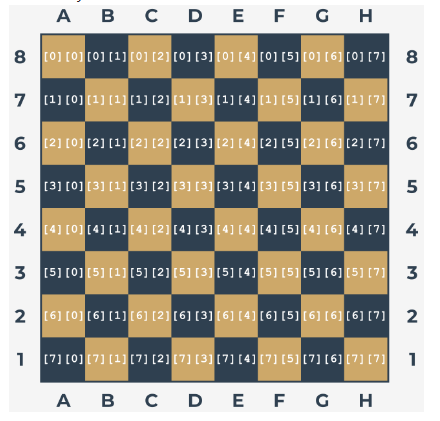

Напишіть код, використоувуючи генератори списків, який створює матрицю 8х8 з пустими клітинками (пуста клітинка задається як "_") для задання шахівниці і розставте чотири тури по кутках шахівниці

```python
# Створення матриці 8х8 з пустими клітинками
chessboard = [['_' for _ in range(8)] for _ in range(8)]

# Розставлення тур по кутках таблиці
chessboard[0][0] = 'R'
chessboard[0][7] = 'R'
chessboard[7][0] = 'R'
chessboard[7][7] = 'R'

# Виведення шахівниці
for row in chessboard:
    print(' '.join(row))
```

[output not shown]

## Контрольні запитання

1. Який вивод наступного фрагмента?

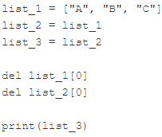

['C']

2. Який вивод наступного фрагмента?

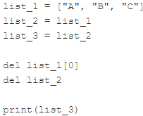

['B', 'C']

3. Який вивод наступного фрагмента?

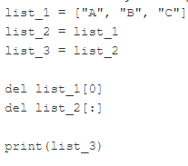

[]

4. Який вивод наступного фрагмента?

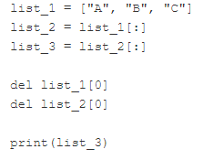

['A', 'B', 'C']